# HW04

Saelin

08/10/2019

**Loading packages needed:**

```r
library(ggplot2)
library(tidyverse)
library(gapminder)
library(knitr)
```

**The Data:**

```r
DT::datatable(gapminder)
```

|  | country | continent | year | lifeExp | pop | gdpPercap |
| --- | --- | --- | --- | --- | --- | --- |
| 1 | Afghanistan | Asia | 1952 | 28.801 | 8425333 | 779.4453145 |
| 2 | Afghanistan | Asia | 1957 | 30.332 | 9240934 | 820.8530296 |
| 3 | Afghanistan | Asia | 1962 | 31.997 | 10267083 | 853.10071 |
| 4 | Afghanistan | Asia | 1967 | 34.02 | 11537966 | 836.1971382 |
| 5 | Afghanistan | Asia | 1972 | 36.088 | 13079460 | 739.9811058 |
| 6 | Afghanistan | Asia | 1977 | 38.438 | 14880372 | 786.11336 |
| 7 | Afghanistan | Asia | 1982 | 39.854 | 12881816 | 978.0114388 |
| 8 | Afghanistan | Asia | 1987 | 40.822 | 13867957 | 852.3959448 |
| 9 | Afghanistan | Asia | 1992 | 41.674 | 16317921 | 649.3413952 |
| 10 | Afghanistan | Asia | 1997 | 41.763 | 22227415 | 635.341351 |

[output cut: 1694 more lines]

## Exercise 1

### Univariate Option 1:

**1.1 Make a tibble with one row per year, and columns for life expectancy for two or more countries**

```r
gapminder_wide <- gapminder %>%
  filter(country %in% c("China", "Taiwan", "Japan")) %>%
  pivot_wider(names_from = country,
              values_from = lifeExp,
               id_cols = year )
kable(gapminder_wide)
```

| year | China | Japan | Taiwan |
| --- | --- | --- | --- |
| 1952 | 44.00000 | 63.030 | 58.50 |
| 1957 | 50.54896 | 65.500 | 62.40 |
| 1962 | 44.50136 | 68.730 | 65.20 |
| 1967 | 58.38112 | 71.430 | 67.50 |
| 1972 | 63.11888 | 73.420 | 69.39 |
| 1977 | 63.96736 | 75.380 | 70.59 |
| 1982 | 65.52500 | 77.110 | 72.16 |
| 1987 | 67.27400 | 78.670 | 73.40 |
| 1992 | 68.69000 | 79.360 | 74.26 |
| 1997 | 70.42600 | 80.690 | 75.25 |
| 2002 | 72.02800 | 82.000 | 76.99 |
| 2007 | 72.96100 | 82.603 | 78.40 |

**1.2 Shape a scatterplot to life expectancy for one country against that of another**

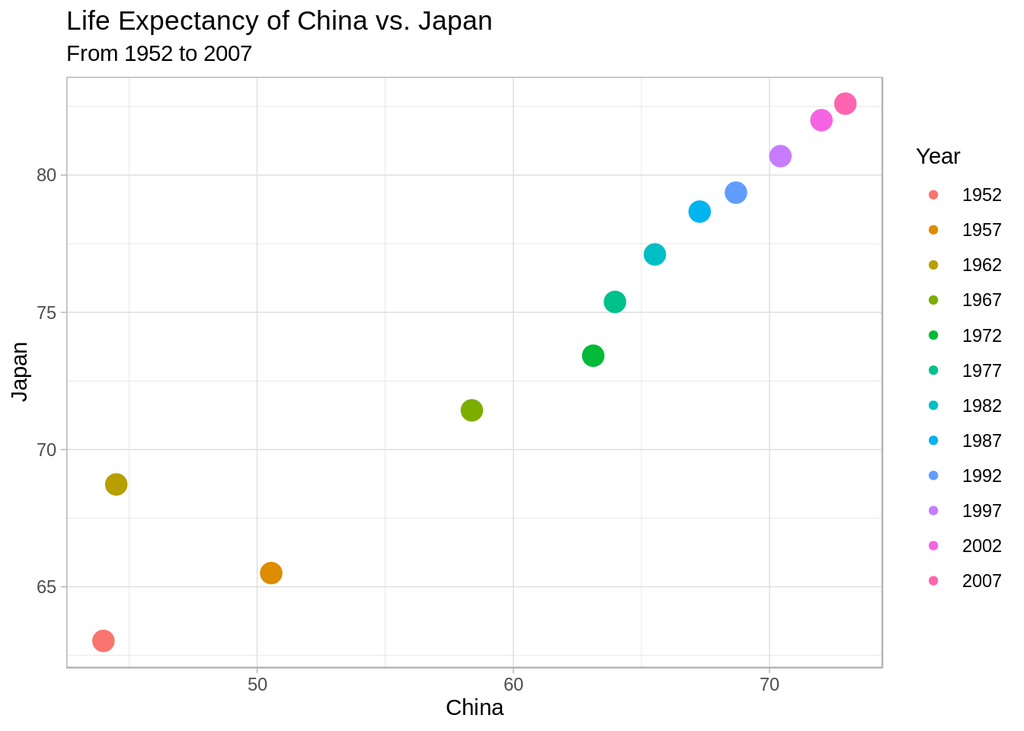

```r
gapminder_wide %>%
  ggplot(aes(China, Japan, color = factor(year), size = 1.5)) + #use factor() to make year discrete
  geom_point() +
  labs(title = "Life Expectancy of China vs. Japan", subtitle = "From 1952 to 2007", color = "Year") +
  guides(size = FALSE) + #remove size legend
  theme_light()
```

**1.3 Re-lengthen the data**

```r
gapminder_long <- gapminder_wide %>%
  pivot_longer(names_to ="Country",
               values_to = "Life Expectancy",
                 cols = -year)
DT::datatable(gapminder_long)
```

|  | year | Country | Life Expectancy |
| --- | --- | --- | --- |
| 1 | 1952 | China | 44 |
| 2 | 1952 | Japan | 63.03 |
| 3 | 1952 | Taiwan | 58.5 |
| 4 | 1957 | China | 50.54896 |
| 5 | 1957 | Japan | 65.5 |
| 6 | 1957 | Taiwan | 62.4 |
| 7 | 1962 | China | 44.50136 |
| 8 | 1962 | Japan | 68.73 |
| 9 | 1962 | Taiwan | 65.2 |
| 10 | 1967 | China | 58.38112 |

[output cut: 26 more lines]

## Exercise 2

### Multivariate Option 2:

**2.1 Make a tibble with one row per year, and columns for life expectancy and GDP per capita for two or more countries**

```r
gap_multi_wide <- gapminder %>%
  filter(country %in% c("China", "Taiwan", "Japan")) %>%
  rename(GDP_PerCap = gdpPercap, Life_Expectancy = lifeExp) %>%
  pivot_wider(id_cols = year,
              names_from = country,
              values_from = c(GDP_PerCap, Life_Expectancy),
              names_sep = " ")
kable(gap_multi_wide)
```

| year | GDP_PerCap China | GDP_PerCap Japan | GDP_PerCap Taiwan | Life_Expectancy China | Life_Expectancy Japan | Life_Expectancy Taiwan |
| --- | --- | --- | --- | --- | --- | --- |
| 1952 | 400.4486 | 3216.956 | 1206.948 | 44.00000 | 63.030 | 58.50 |
| 1957 | 575.9870 | 4317.694 | 1507.861 | 50.54896 | 65.500 | 62.40 |
| 1962 | 487.6740 | 6576.649 | 1822.879 | 44.50136 | 68.730 | 65.20 |
| 1967 | 612.7057 | 9847.789 | 2643.859 | 58.38112 | 71.430 | 67.50 |
| 1972 | 676.9001 | 14778.786 | 4062.524 | 63.11888 | 73.420 | 69.39 |
| 1977 | 741.2375 | 16610.377 | 5596.520 | 63.96736 | 75.380 | 70.59 |
| 1982 | 962.4214 | 19384.106 | 7426.355 | 65.52500 | 77.110 | 72.16 |
| 1987 | 1378.9040 | 22375.942 | 11054.562 | 67.27400 | 78.670 | 73.40 |
| 1992 | 1655.7842 | 26824.895 | 15215.658 | 68.69000 | 79.360 | 74.26 |
| 1997 | 2289.2341 | 28816.585 | 20206.821 | 70.42600 | 80.690 | 75.25 |
| 2002 | 3119.2809 | 28604.592 | 23235.423 | 72.02800 | 82.000 | 76.99 |
| 2007 | 4959.1149 | 31656.068 | 28718.277 | 72.96100 | 82.603 | 78.40 |

**2.2 Re-lengthen the data**

```r
gap_multi_long <- gap_multi_wide %>%
  pivot_longer(cols = -year,
               names_to = c("Metric","country"),
               values_to= c("Measurement"),
               names_sep = " ")
DT::datatable(gap_multi_long)
```

|  | year | Metric | country | Measurement |
| --- | --- | --- | --- | --- |
| 1 | 1952 | GDP_PerCap | China | 400.448611 |
| 2 | 1952 | GDP_PerCap | Japan | 3216.956347 |
| 3 | 1952 | GDP_PerCap | Taiwan | 1206.947913 |
| 4 | 1952 | Life_Expectancy | China | 44 |
| 5 | 1952 | Life_Expectancy | Japan | 63.03 |
| 6 | 1952 | Life_Expectancy | Taiwan | 58.5 |
| 7 | 1957 | GDP_PerCap | China | 575.9870009 |
| 8 | 1957 | GDP_PerCap | Japan | 4317.694365 |
| 9 | 1957 | GDP_PerCap | Taiwan | 1507.86129 |
| 10 | 1957 | Life_Expectancy | China | 50.54896 |

[output cut: 62 more lines]

## Exercise 3

Loading CSVs with guest and email info:

```r
guest <- read_csv("https://raw.githubusercontent.com/STAT545-UBC/Classroom/master/data/wedding/attend.csv")
email <- read_csv("https://raw.githubusercontent.com/STAT545-UBC/Classroom/master/data/wedding/emails.csv")
```

**A look at the data:**

```r
DT::datatable(email)
```

|  | guest | email |
| --- | --- | --- |
| 1 | Sommer Medrano, Phillip Medrano, Blanka Medrano, Emaan Medrano | sommm@gmail.com |
| 2 | Blair Park, Nigel Webb | bpark@gmail.com |
| 3 | Sinead English | singlish@hotmail.ca |
| 4 | Ayra Marks | marksa42@gmail.com |
| 5 | Jolene Welsh, Hayley Booker | jw1987@hotmail.com |
| 6 | Amayah Sanford, Erika Foley | erikaaaaaa@gmail.com |
| 7 | Ciaron Acosta | shining_ciaron@gmail.com |
| 8 | Diana Stuart | doodledianastu@gmail.com |
| 9 | Daisy-May Caldwell, Martin Caldwell, Violet Caldwell, Nazifa Caldwell, Eric Caldwell | caldwellfamily5212@gmail.com |
| 10 | Rosanna Bird, Kurtis Frost | rosy1987b@gmail.com |

[output cut: 4 more lines]

```r
DT::datatable(guest)
```

|  | party | name | meal_wedding | meal_brunch | attendance_wedding | attendance_brunch | attendance_golf |
| --- | --- | --- | --- | --- | --- | --- | --- |
| 1 | 1 | Sommer Medrano | PENDING | PENDING | PENDING | PENDING | PENDING |
| 2 | 1 | Phillip Medrano | vegetarian | Menu C | CONFIRMED | CONFIRMED | CONFIRMED |
| 3 | 1 | Blanka Medrano | chicken | Menu A | CONFIRMED | CONFIRMED | CONFIRMED |
| 4 | 1 | Emaan Medrano | PENDING | PENDING | PENDING | PENDING | PENDING |
| 5 | 2 | Blair Park | chicken | Menu C | CONFIRMED | CONFIRMED | CONFIRMED |
| 6 | 2 | Nigel Webb |  |  | CANCELLED | CANCELLED | CANCELLED |
| 7 | 3 | Sinead English | PENDING | PENDING | PENDING | PENDING | PENDING |
| 8 | 4 | Ayra Marks | vegetarian | Menu B | PENDING | PENDING | PENDING |
| 9 | 5 | Atlanta Connolly | PENDING | PENDING | PENDING | PENDING | PENDING |
| 10 | 5 | Denzel Connolly | fish | Menu B | CONFIRMED | CONFIRMED | CONFIRMED |

[output cut: 20 more lines]

**3.1 For each guest in the guestlist (guest tibble), add a column for email address, which can be found in email table**

```r
emails <- email %>%  #modify email to make it "joinable"
  rename("name" = guest) %>%   #rename guest to name
  separate_rows("name", sep =", ")  # seperate names within one cell into separate rows

DT::datatable(left_join(guest, emails))  # join the tables, adding email column to guest
```

|  | party | name | meal_wedding | meal_brunch | attendance_wedding | attendance_brunch | attendance_golf | email |
| --- | --- | --- | --- | --- | --- | --- | --- | --- |
| 1 | 1 | Sommer Medrano | PENDING | PENDING | PENDING | PENDING | PENDING | sommm@gmail.com |
| 2 | 1 | Phillip Medrano | vegetarian | Menu C | CONFIRMED | CONFIRMED | CONFIRMED | sommm@gmail.com |
| 3 | 1 | Blanka Medrano | chicken | Menu A | CONFIRMED | CONFIRMED | CONFIRMED | sommm@gmail.com |
| 4 | 1 | Emaan Medrano | PENDING | PENDING | PENDING | PENDING | PENDING | sommm@gmail.com |
| 5 | 2 | Blair Park | chicken | Menu C | CONFIRMED | CONFIRMED | CONFIRMED | bpark@gmail.com |
| 6 | 2 | Nigel Webb |  |  | CANCELLED | CANCELLED | CANCELLED | bpark@gmail.com |
| 7 | 3 | Sinead English | PENDING | PENDING | PENDING | PENDING | PENDING | singlish@hotmail.ca |
| 8 | 4 | Ayra Marks | vegetarian | Menu B | PENDING | PENDING | PENDING | marksa42@gmail.com |
| 9 | 5 | Atlanta Connolly | PENDING | PENDING | PENDING | PENDING | PENDING |  |
| 10 | 5 | Denzel Connolly | fish | Menu B | CONFIRMED | CONFIRMED | CONFIRMED |  |

[output cut: 20 more lines]

**3.2 Who do we have emails for, yet are not on the guestlist?**

```r
emails <- email %>%  #modify email to make it "joinable"
  rename("name" = guest) %>%   #rename guest to name
  separate_rows("name", sep =", ")  # seperate names within one cell into separate rows

kable(anti_join(emails, guest)) #filter-join the tables, keeping only rows in emails that aren't in guest
```

| name | email |
| --- | --- |
| Turner Jones | tjjones12@hotmail.ca |
| Albert Marshall | themarshallfamily1234@gmail.com |
| Vivian Marshall | themarshallfamily1234@gmail.com |

**3.3 Make a guestlist that includes everyone we have emails for (in addition to those on the original guestlist)**

```r
emails <- email %>%  #modify email to make it "joinable"
  rename("name" = guest) %>%   #rename guest to name
  separate_rows("name", sep =", ")  # seperate names within one cell into separate rows

DT::datatable(full_join(guest,emails))
```

|  | party | name | meal_wedding | meal_brunch | attendance_wedding | attendance_brunch | attendance_golf | email |
| --- | --- | --- | --- | --- | --- | --- | --- | --- |
| 1 | 1 | Sommer Medrano | PENDING | PENDING | PENDING | PENDING | PENDING | sommm@gmail.com |
| 2 | 1 | Phillip Medrano | vegetarian | Menu C | CONFIRMED | CONFIRMED | CONFIRMED | sommm@gmail.com |
| 3 | 1 | Blanka Medrano | chicken | Menu A | CONFIRMED | CONFIRMED | CONFIRMED | sommm@gmail.com |
| 4 | 1 | Emaan Medrano | PENDING | PENDING | PENDING | PENDING | PENDING | sommm@gmail.com |
| 5 | 2 | Blair Park | chicken | Menu C | CONFIRMED | CONFIRMED | CONFIRMED | bpark@gmail.com |
| 6 | 2 | Nigel Webb |  |  | CANCELLED | CANCELLED | CANCELLED | bpark@gmail.com |
| 7 | 3 | Sinead English | PENDING | PENDING | PENDING | PENDING | PENDING | singlish@hotmail.ca |
| 8 | 4 | Ayra Marks | vegetarian | Menu B | PENDING | PENDING | PENDING | marksa42@gmail.com |
| 9 | 5 | Atlanta Connolly | PENDING | PENDING | PENDING | PENDING | PENDING |  |
| 10 | 5 | Denzel Connolly | fish | Menu B | CONFIRMED | CONFIRMED | CONFIRMED |  |

[output cut: 23 more lines]